# Bagla_lab6_0227

Aman Bagla

26 February 2019

## Question 1

```r
library(rpart)
library(rpart.plot)
library(caret)
library(e1071)
setwd("C:/Users/amanb/Desktop/Predictive Modeling")
TCcount <-read.csv("TCcount.csv")
set.seed(2)
tain.row <- sample(1:nrow(TCcount), 0.8*nrow(TCcount))
tc.train <- TCcount[tain.row,]
tc.test <- TCcount[-tain.row,]

model1 <- rpart(TS~SST+ENSO+NAO, data=tc.train,method="class")
summary(model1)
```

```
## Call:
## rpart(formula = TS ~ SST + ENSO + NAO, data = tc.train, method = "class")
##   n= 90
##
##           CP nsplit rel error    xerror       xstd
## 1 0.11538462      0 1.0000000 1.0897436 0.02785984
## 2 0.03846154      1 0.8846154 0.8846154 0.05144206
## 3 0.02564103      3 0.8076923 0.9230769 0.04865043
## 4 0.01282051      5 0.7564103 0.9358974 0.04760691
## 5 0.01000000      7 0.7307692 0.9615385 0.04532736
##
## Variable importance
## ENSO  SST  NAO
##   56   30   14
##
## Node number 1: 90 observations,    complexity param=0.1153846
##   predicted class=11  expected loss=0.8666667  P(node) =1
##     class counts:     1     2     1     4     7    10     5     9     8     6    12     7     5     3     3     1     4     1     1
##    probabilities: 0.011 0.022 0.011 0.044 0.078 0.111 0.056 0.100 0.089 0.067 0.133 0.078 0.056 0.033 0.033 0.011 0.044 0.011 0.011
##   left son=2 (52 obs) right son=3 (38 obs)
##   Primary splits:
##       ENSO < -0.1418333 to the right, improve=3.360369, (0 missing)
##       NAO  < 2.8625     to the left,  improve=2.048346, (0 missing)
##       SST  < 27.55225   to the left,  improve=1.752168, (0 missing)
##   Surrogate splits:
##       SST < 27.2507    to the left,  agree=0.600, adj=0.053, (0 split)
##       NAO < -1.6       to the right, agree=0.589, adj=0.026, (0 split)
##
## Node number 2: 52 observations,    complexity param=0.03846154
##   predicted class=6   expected loss=0.8076923  P(node) =0.5777778
##     class counts:     1     2     1     2     5    10     5     5     6     2     1     4     0     1     2     1     3     0     1
##    probabilities: 0.019 0.038 0.019 0.038 0.096 0.192 0.096 0.096 0.115 0.038 0.019 0.077 0.000 0.019 0.038 0.019 0.058 0.000 0.019
##   left son=4 (45 obs) right son=5 (7 obs)
##   Primary splits:
##       NAO  < 2.70375    to the left,  improve=2.047985, (0 missing)
##       SST  < 27.3274    to the left,  improve=1.921795, (0 missing)
##       ENSO < 2.502227   to the left,  improve=1.825763, (0 missing)
##   Surrogate splits:
##       ENSO < 14.75696   to the left,  agree=0.981, adj=0.857, (0 split)
##       SST  < 26.41545   to the right, agree=0.904, adj=0.286, (0 split)
```

[output cut: 83 more lines]

```
##
## Node number 17: 10 observations
##   predicted class=6   expected loss=0.6  P(node) =0.1111111
##     class counts:     0     0     0     0     1     4     0     0     2     0     0     3     0     0     0     0     0     0     0
##    probabilities: 0.000 0.000 0.000 0.000 0.100 0.400 0.000 0.000 0.200 0.000 0.000 0.300 0.000 0.000 0.000 0.000 0.000 0.000 0.000
##
## Node number 32: 9 observations
##   predicted class=4   expected loss=0.7777778  P(node) =0.1
##     class counts:     1     1     1     2     2     0     2     0     0     0     0     0     0     0     0     0     0     0     0
##    probabilities: 0.111 0.111 0.111 0.222 0.222 0.000 0.222 0.000 0.000 0.000 0.000 0.000 0.000 0.000 0.000 0.000 0.000 0.000 0.000
##
## Node number 33: 17 observations
##   predicted class=6   expected loss=0.6470588  P(node) =0.1888889
##     class counts:     0     1     0     0     1     6     3     2     1     1     1     1     0     0     0     0     0     0     0
##    probabilities: 0.000 0.059 0.000 0.000 0.059 0.353 0.176 0.118 0.059 0.059 0.059 0.059 0.000 0.000 0.000 0.000 0.000 0.000 0.000
```

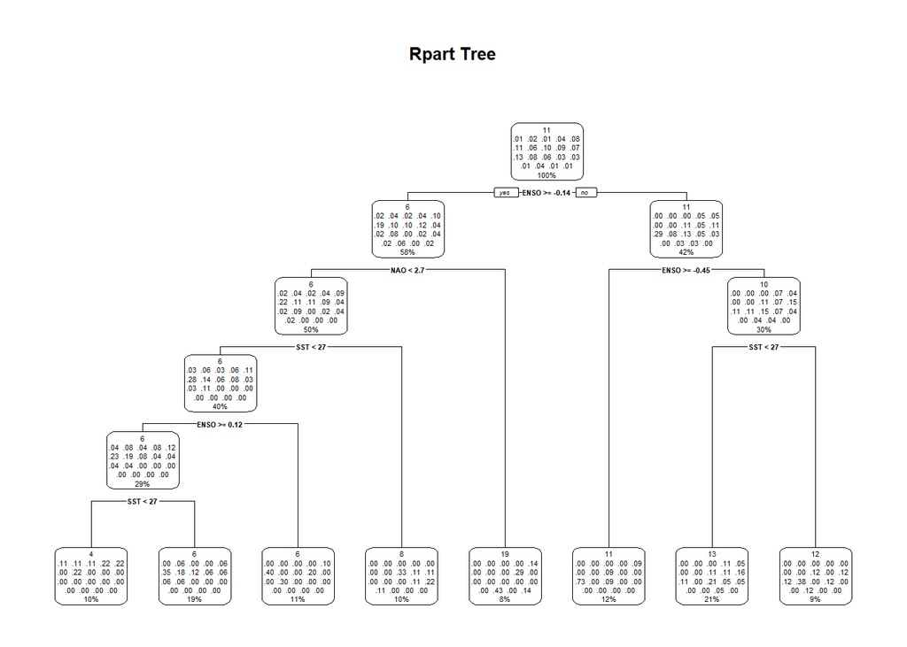

```r
rpart.plot(model1, main="Rpart Tree")
```

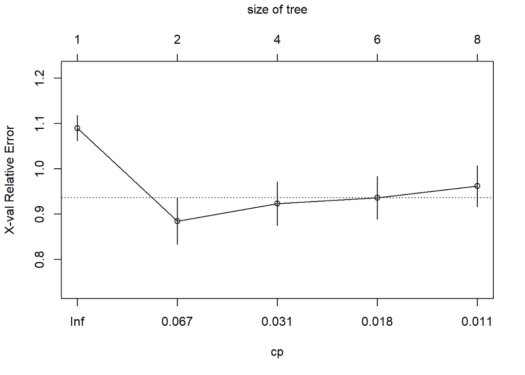

```r
plotcp(model1)
```

```r
summary(model1)
```

```
## Call:
## rpart(formula = TS ~ SST + ENSO + NAO, data = tc.train, method = "class")
##   n= 90
##
##           CP nsplit rel error    xerror       xstd
## 1 0.11538462      0 1.0000000 1.0897436 0.02785984
## 2 0.03846154      1 0.8846154 0.8846154 0.05144206
## 3 0.02564103      3 0.8076923 0.9230769 0.04865043
## 4 0.01282051      5 0.7564103 0.9358974 0.04760691
## 5 0.01000000      7 0.7307692 0.9615385 0.04532736
##
## Variable importance
## ENSO  SST  NAO
##   56   30   14
##
## Node number 1: 90 observations,    complexity param=0.1153846
##   predicted class=11  expected loss=0.8666667  P(node) =1
##     class counts:     1     2     1     4     7    10     5     9     8     6    12     7     5     3     3     1     4     1     1
##    probabilities: 0.011 0.022 0.011 0.044 0.078 0.111 0.056 0.100 0.089 0.067 0.133 0.078 0.056 0.033 0.033 0.011 0.044 0.011 0.011
##   left son=2 (52 obs) right son=3 (38 obs)
##   Primary splits:
##       ENSO < -0.1418333 to the right, improve=3.360369, (0 missing)
##       NAO  < 2.8625     to the left,  improve=2.048346, (0 missing)
##       SST  < 27.55225   to the left,  improve=1.752168, (0 missing)
##   Surrogate splits:
##       SST < 27.2507    to the left,  agree=0.600, adj=0.053, (0 split)
##       NAO < -1.6       to the right, agree=0.589, adj=0.026, (0 split)
##
## Node number 2: 52 observations,    complexity param=0.03846154
##   predicted class=6   expected loss=0.8076923  P(node) =0.5777778
##     class counts:     1     2     1     2     5    10     5     5     6     2     1     4     0     1     2     1     3     0     1
##    probabilities: 0.019 0.038 0.019 0.038 0.096 0.192 0.096 0.096 0.115 0.038 0.019 0.077 0.000 0.019 0.038 0.019 0.058 0.000 0.019
##   left son=4 (45 obs) right son=5 (7 obs)
##   Primary splits:
##       NAO  < 2.70375    to the left,  improve=2.047985, (0 missing)
##       SST  < 27.3274    to the left,  improve=1.921795, (0 missing)
##       ENSO < 2.502227   to the left,  improve=1.825763, (0 missing)
##   Surrogate splits:
##       ENSO < 14.75696   to the left,  agree=0.981, adj=0.857, (0 split)
##       SST  < 26.41545   to the right, agree=0.904, adj=0.286, (0 split)
```

[output cut: 83 more lines]

```
##
## Node number 17: 10 observations
##   predicted class=6   expected loss=0.6  P(node) =0.1111111
##     class counts:     0     0     0     0     1     4     0     0     2     0     0     3     0     0     0     0     0     0     0
##    probabilities: 0.000 0.000 0.000 0.000 0.100 0.400 0.000 0.000 0.200 0.000 0.000 0.300 0.000 0.000 0.000 0.000 0.000 0.000 0.000
##
## Node number 32: 9 observations
##   predicted class=4   expected loss=0.7777778  P(node) =0.1
##     class counts:     1     1     1     2     2     0     2     0     0     0     0     0     0     0     0     0     0     0     0
##    probabilities: 0.111 0.111 0.111 0.222 0.222 0.000 0.222 0.000 0.000 0.000 0.000 0.000 0.000 0.000 0.000 0.000 0.000 0.000 0.000
##
## Node number 33: 17 observations
##   predicted class=6   expected loss=0.6470588  P(node) =0.1888889
##     class counts:     0     1     0     0     1     6     3     2     1     1     1     1     0     0     0     0     0     0     0
##    probabilities: 0.000 0.059 0.000 0.000 0.059 0.353 0.176 0.118 0.059 0.059 0.059 0.059 0.000 0.000 0.000 0.000 0.000 0.000 0.000
```

Best model chosen here is as per minimum relative error between Cp & x-error.

Checking model performance on In-sample and Out-of-sample data using %age of correct predicitons.

```r
model1.pred.IS <- predict(model1,type="class")
train.res.mat <- table(model1.pred.IS,tc.train$TS)
correct.pred.train.model1 <- sum(train.res.mat[row(train.res.mat) == col(train.res.mat)])
per.accuracy.train.model1 <- correct.pred.train.model1*100/length(model1.pred.IS)
per.accuracy.train.model1
```

```
## [1] 36.66667
```

```r
model1.pred.OS <- predict(model1,newdata = tc.test,type="class")
test.res.mat <- table(model1.pred.OS,tc.test$TS)
correct.pred.test.model1 <- sum(test.res.mat[row(test.res.mat) == col(test.res.mat)])
per.accuracy.test.model1 <- correct.pred.test.model1*100/length(model1.pred.OS)
per.accuracy.test.model1
```

```
## [1] 0
```

Prediction accuracy of model1 on in-sample and out-of-sample are 36.6666667 % & 0 % respectively.

However in this case, instead of using %age of correct prediction, comparing using MSE makes more sense.

```r
SSE.train.model1 <- sum((tc.train$TS - as.numeric(model1.pred.IS)-1)^2)/nrow(tc.train)
SSE.train.model1
```

```
## [1] 16.4
```

```r
SSE.test.model1 <- sum((tc.test$TS - as.numeric(model1.pred.OS)-1)^2)/nrow(tc.test)
SSE.test.model1
```

```
## [1] 21
```

## Question 2

Percentage of correct prediction for each cross-fold is shown in below graph.

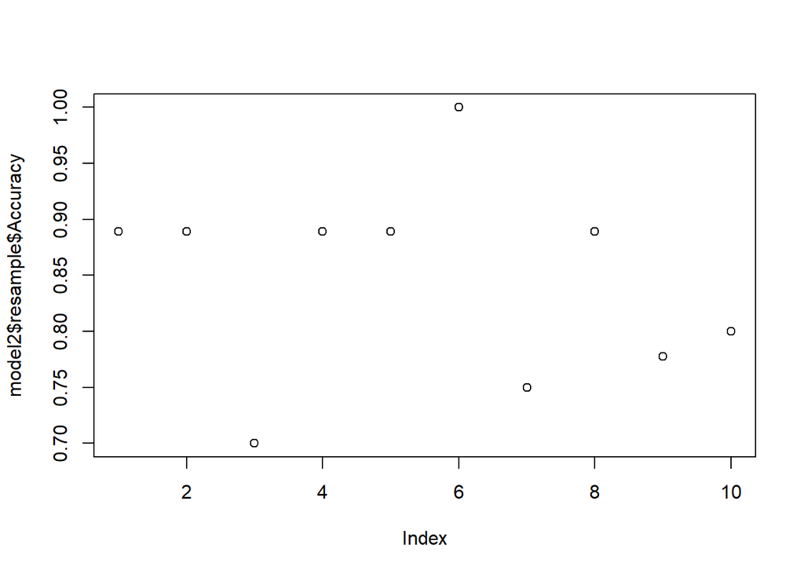

```r
TCcount$perc <- as.factor(ifelse(TCcount$TS <= quantile(TCcount$TS, probs=0.8), 0, 1))
tcnew.train <- TCcount[tain.row,]
tcnew.test <- TCcount[-tain.row,]

set.seed(1)
train_control <- trainControl(method = "cv", number = 10)
model2 <- train(perc~SST+ENSO+NAO, data=tcnew.train, trControl = train_control, method="rpart")

plot(model2$resample$Accuracy)
```

To compare model1 & model2, model2’s accuracy was checked on in-sample and out-of-sample data and results are as shown below.

```r
model2.pred.IS <- predict(model2,type="raw")
table(model2.pred.IS,tcnew.train$perc)
```

```
##
## model2.pred.IS  0  1
##              0 70 11
##              1  2  7
```

```r
model2.pred.OS <- predict(model2,newdata = tcnew.test,type="raw")
table(model2.pred.OS,tcnew.test$perc)
```

```
##
## model2.pred.OS  0  1
##              0 15  4
##              1  3  1
```

```r
per.accuracy.train.model2 <- sum(table(model2.pred.IS,tcnew.train$perc)[c(1,4)])*100/sum(table(model2.pred.IS,tcnew.train$perc))
per.accuracy.train.model2
```

```
## [1] 85.55556
```

```r
per.accuracy.test.model2 <- sum(table(model2.pred.OS,tcnew.test$perc)[c(1,4)])*100/sum(table(model2.pred.OS,tcnew.test$perc))
per.accuracy.test.model2
```

```
## [1] 69.56522
```

Here, we can see that accuracy of model2 is much better than model1 as it has now become a classifiation type of problem rather actual quantative value prediction hence inherent predicion accuracy is higer.

## Question 3

```r
set.seed(1)
model3 <- train(TS~SST+ENSO+NAO, data=tcnew.train, trControl = train_control, method="rpart1SE")
model3.pred.IS <- predict(model3,type="raw")
model3.pred.OS <- predict(model3, newdata = tcnew.test, type="raw")
SSE.train.rpart <- sum((tcnew.train$TS - as.numeric(model3.pred.IS)-1)^2)/nrow(tcnew.train)
SSE.train.rpart
```

```
## [1] 12.12477
```

```r
SSE.test.rpart <- sum((tcnew.test$TS - as.numeric(model3.pred.OS)-1)^2)/nrow(tcnew.train)
SSE.test.rpart
```

```
## [1] 5.487247
```

```r
set.seed(1)
model4 <- train(TS~SST+ENSO+NAO, data=tcnew.train, trControl = train_control, method="cforest")
model4.pred.IS <- predict(model4,type="raw")
model4.pred.OS <- predict(model4, newdata = tcnew.test, type="raw")
SSE.train.randforst <- sum((tcnew.train$TS - as.numeric(model4.pred.IS)-1)^2)/nrow(tcnew.train)
SSE.train.randforst
```

```
## [1] 10.28635
```

```r
SSE.test.randforst <- sum((tcnew.test$TS - as.numeric(model4.pred.OS)-1)^2)/nrow(tcnew.train)
SSE.test.randforst
```

```
## [1] 4.119886
```

Looking at the MSE values of both the model i.e. model3 (Using rpart with cross validation) & model4 (using random Forest with cross validation) on both in-sample and out-of-sample data, we can see that the MSE values are better while using random forest methodology, hence Random Forest is better for this case.

```r
comparison <- matrix(c(SSE.train.rpart,SSE.test.rpart,SSE.train.randforst,SSE.test.randforst), nrow = 2)
rownames(comparison) <- c("MSE_Train","MSE_Test")
colnames(comparison) <- c("Rpart", "Random Forest")
comparison
```

```
##               Rpart Random Forest
## MSE_Train 12.124770     10.286354
## MSE_Test   5.487247      4.119886
```